# Introducción al análisis de redes con R

Martín Montané

2020

# La relevancia de las redes/grafos

Durante las últimas décadas la representación de diversos sistemas en redes o grafos se ha vuelto un recurso cada vez más usado en diversas ramas científicas, pero también en aplicaciones profesionales. Desde el análisis de un conjunto de routers que sostienen una red de una empresa, el sistema nervioso de cada uno de los animales de este planeta, internet hasta la capacidad de los países para exportar un determinado producto son todos dominios donde el análisis a través de grafos tiene algo para aportar.

Vamos a introducirnos al análisis de redes a través de un ejemplo con datos reales y utilizando R. Al menos en el 2020 existe una amplia cantidad de paquetes que permiten hacer distintos análisis y gráficos para redes en R. **igraph** ya es una librería madura con muchas funciones que nos permite trabajar con nuestros gráfos sin mayores problemas. Sin embargo **tidygraph** es una herramienta que nos permite trabajar a los grafos de una manera similar a la cual trabajamos al resto de los tipos de datos en R. Por último **ggraph** también hace un esfuerzo similar para habilitar la misma sintáxis que usamos en ggplot, pero esta vez para los gráficos. Vamos a cargar estos tres paquetes e introducir a los datos con los que vamos a trabajar

```r
library(igraph)
library(tidygraph)
library(ggraph)
library(tidyverse)
```

# Los datos

En esta nota de clase vamos a trabajar con unos datos laborales muy interesantes. Van a encontrar otros tipo de datos más clásicos como series, películas o páginas de internet para replicar lo que vamos a ver hoy.

Estos datos laborales consisten en ocupaciones específicas de EE.UU. La encuesta del Panel Study of Income Dynamics (PSID) realiza encuestas a un conjunto de hogares - y sus derivados - desde 1968 en adelante. En cada una de esas encuestas se releva un conjunto de preguntas muy variadas, desde datos de educación, riqueza, ingresos, satisfacción con la vida, entre muchas otras.

Una de las preguntas que hacen es la ocupación que desempeñan en su actual puesto de empleo. Por ejemplo, pueden trabajar de enfermeros/as, psicólogos/as, ingenieros/as en sistemas, economistas, arquitectos/as, entre otras profesiones. ¿Podemos aprender sobre cuáles son las ocupaciones que más se parecen entre ellas analizando los cambios de empleo de las personas relevadas?

Esta información puede ser muy importante para cuestiones tales como el cambio tecnológico a las políticas educativas y de formación laboral ¡Y podemos usar grafos para entender un poco más sobre este tema tan importante!

Vamos a cargar dos datasets. El primero tiene es un dataset que contiene a un gran porcentaje de las ocupaciones de EE.UU. e información sobre las transiciones laborales de las personas. Como es un archivo csv podemos usar **read_delim()** para leerlo a nuestra sesión de R

```r
similitud <- read_delim("https://github.com/martinmontane/martinmontane.github.io/raw/master/similitud.csv",delim=";")
glimpse(similitud)
```

```
## Rows: 140,589
## Columns: 4
## $ sectorSalida  <chr> "11-1010", "11-1010", "11-1010", "11-1010", "11-1010"...
## $ sectorLlegada <chr> "11-1010", "11-1020", "11-2010", "11-2020", "11-2030"...
## $ RijCorregido  <dbl> -1.0000000, 0.9159743, -1.0000000, 0.6218945, -1.0000...
## $ flow          <dbl> 0, 1, 0, 1, 0, 0, 0, 1, 1, 0, 0, 0, 0, 1, 2, 1, 0, 0,...
```

Estos datos de similitud cuentan específicamente con cuatro columnas:

- **sectorSalida**: identifica el código de ocupación de “salida”
- **sectorLlegada**: identifica el código de ocupación de “llegada”
- **RijCorregido**: Medida de similitud entre la ocupación de salida i y la ocupación de llegada j
- **flow**: cantidad de transiciones que se observaron saliendo desde el sector de salida y llegaron al sector de llegada

Por ejemplo, el flujo entre la ocupación 11-1010 y 11-1010 es 0: ninguna persona cambió de empleo y mantuvo esa ocupación. Por esta razón, RijCorregido marca el valor -1: estas ocupaciones no se parecen en nada (o eso asumimos). Por otro lado, sí se verifica una persona que salió desde 11-1010 hacia 11-1020, y por esta razón tiene un valor cercano a 1, que es la máxima similitud entre las dos ocupaciones. **RijCorregido** no es muy robusta a pocos casos como estos que observamos, por lo que vamos a quedarnos con aquellos que al menos tengan 10 observaciones

```r
similitud <- similitud %>% filter(flow>10)
glimpse(similitud)
```

```
## Rows: 425
## Columns: 4
## $ sectorSalida  <chr> "11-2020", "11-2020", "11-2020", "11-2020", "11-2020"...
## $ sectorLlegada <chr> "11-9190", "41-1010", "41-2030", "41-3090", "41-4010"...
## $ RijCorregido  <dbl> 0.6045836, 0.7280474, 0.5294999, 0.6888004, 0.7288310...
## $ flow          <dbl> 75, 16, 30, 11, 24, 28, 30, 19, 11, 15, 12, 31, 40, 1...
```

Nos quedamos con muchas menos ocupaciones, pero al menos tenemos mayor confianza sobre el análisis que sigue.

Ahora bien, estos códigos están asociados a una ocupación en particular. Vamos a cargar la descripción de estos códigos, solo para poder entender nuestro análisis más adelante

```r
descripcion <- read_delim("https://raw.githubusercontent.com/martinmontane/martinmontane.github.io/master/descripcion.csv",delim=";")
glimpse(descripcion)
```

```
## Rows: 461
## Columns: 2
## $ broadGroup <chr> "11-1010", "11-1020", "11-1030", "11-2010", "11-2020", "...
## $ Desc       <chr> "Chief Executives", "General and Operations Managers", "...
```

Perfecto, ahora ya podemo pasar a nuestra primera tarea de esta clase: convertir a estos datos en grafos

# Creando un grafo

**tidygraph** nos brinda la posibilidad de crear grafos desde diferentes objetos. En este caso, tenemos un data.frame que se llama “similitud” que contiene la materia prima para construir a nuestro grafo… pero el primer paso es preguntarnos qué queremos modelar mediante un grafo.

Nuestro objetivo es analizar a las ocupaciones (serán nuestros nodos) mediante el estudio de la relación de similitud que tienen entre ellas (serán nuestras aristas), que a su vez está basado en flujos observados de cambio de empleo de trabajadores y trabajadoras. Queremos hacernos preguntas como ¿Cuál es el camino más corto para llegar desde la ocupación x hasta la ocupación y? Esta podría ser una pregunta relevante para pensar las trayectorías laborales de las personas. O simplemente podríamos querer preguntarnos cuáles son las ocupaciones con pocos lazos con otras ocupaciones, para conocer cuáles son los trabajadores/as que quizás tengan problemas para cambiar de ocupación. Estas son solo algunas de las preguntas que podríamos hacernos con grafos.

```r
similitud <- similitud %>%
               mutate(RijSimple=ifelse(RijCorregido>0,1,0)) %>%
               filter(RijSimple == 1)
```

Ahora ya podemos crear un grafo en R con la función **graph_from_data_frame()** del paquete *igraph*. Lo que hará es seleccionar la primera y la segunda de nuestro data frame y las usará como nodos. Si ninguna columna tiene el nombre de “weight”, entonces el grafo será no ponderado. Por otro lado, el argumento “directed” indica si queremos crear un grafo direccionado o no. Un grafo direccionado es aquel en el cuál las aristas tienen un “sentido”. Imaginen que los nodos son aeropuertos y las aristas son rutas de avión. En este caso, la ruta de avión tendrá un nodo de inicio y de destino, por lo cual tiene sentido trabajar con un grafo direccionado. Ahora imaginen que cada nodo es una persona y las aristas indican si están casados/as, en este último ejemplo no tendría sentido trabajar grafos direccionados.

Aunque en nuestro ejemplo existe cierta dirección (la medida de similitud no es estrictamente simétrica), vamos a ignorarlo y crear un grafo sin dirección (ya prestaremos atención a esto):

```r
grafo <- graph_from_data_frame(similitud,directed = FALSE)
class(grafo)
```

```
## [1] "igraph"
```

La clase del objeto grafo es **igraph**, lo que nos permite comenzar a trabajar sobre la estructura de los grafos. Para empezar, frafiquemos nuestra red:

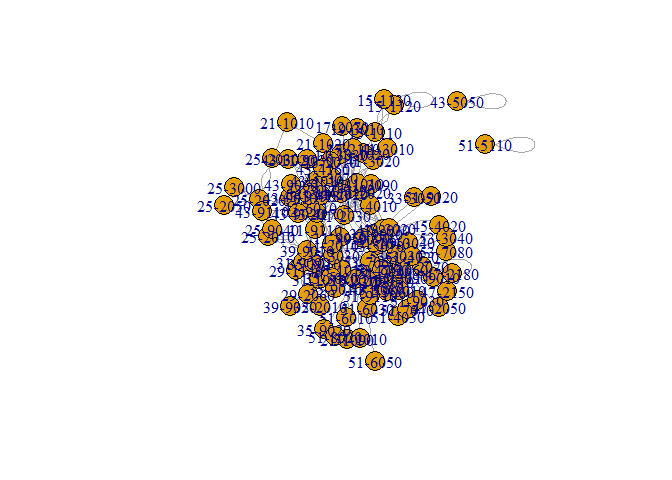

```r
plot(grafo)
```

La función **plot()** por default devuelve esto que está con demasiado texto. No se preocupen, ya vamos a ver cómo mejorar nuestros gráficos, pero prestemos atención a un par de detalles. Para empezar, queda claro que hay dos nodos (ocupaciones) que solo tienen conexión consigo mismas, verdad? Lo pueden ver en en la 51-5110 y 43-5050. Esto significa que la ocupación más similar para esas ocupaciones son ellas mismas… y esto suele suceder bastante. Debido a que nos interesa analizar la similitud **entre** ocupaciones, estas similitudes no son de mayor interés. Vamos a ver como trabajar con esto en la sección de data wrangling para grafos

# Data wrangling para grafos

Cada tipo de datos precisa unas herraminetas particulares para su manipulación de datos - y, muchas veces, también su visualización. Los grafos no son una excepción a esta regla. Podemos usar **tidygraph** o **igraph** para estas tareas, según la operación específica que queramos hacer.

Lo primero que vamos a querer hacer con nuestro grafo es *simplificarlo*. Es una herramienta para eliminar, por ejemplo, aristas que conectan a un nodo con si mismo. Tenemos la función **simplify()** para lograr esto:

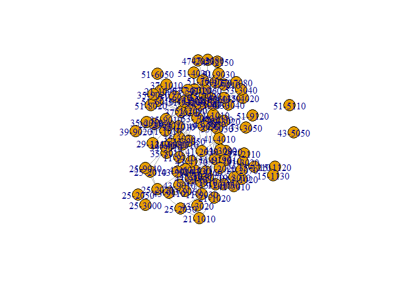

```r
grafo <- igraph::simplify(grafo,remove.loops=TRUE)
plot(grafo)
```

Ya eliminamos esas conexiones, ahora vamos a seguir haciendo unas transfomaciones, pero esta vez convirtiendo el objeto igraph en uno de tidygraph, que nos permitirá hacer distintas manipulaciones dentro de un entorno **tidy**

```r
grafo <- as_tbl_graph(grafo)
class(grafo)
```

```
## [1] "tbl_graph" "igraph"
```

Ya tenemos un objeto tidygraph… veamos que nos dice cuando lo mandamos a la consola (importante: siempre que pasamos a la consola un nombre de un objeto es lo mismo que si hicieramos **print(nombreDelObjeto)**. Pruebenlo)

```r
grafo
```

```
## # A tbl_graph: 98 nodes and 237 edges
## #
## # An undirected simple graph with 3 components
## #
## # Node Data: 98 x 1 (active)
##   name
##   <chr>
## 1 11-2020
## 2 11-3030
## 3 11-9010
## 4 11-9030
## 5 11-9050
## 6 11-9110
## # ... with 92 more rows
## #
## # Edge Data: 237 x 2
##    from    to
##   <int> <int>
## 1     1     7
## 2     1    36
## 3     1    39
## # ... with 234 more rows
```

En **tidygraph** nodos y aristas tienen data.frames asociados. Solo uno de ellos puede estar “activado” y es sobre el cual las operaciones de data wrangling van a funcionar. Por ejemplo, imaginen que quiero agregarle una columna que diga “Nodo” al dataset de mis nodos, directamente puedo usar **mutate()**

```r
grafo <- grafo %>% mutate(nodo="nodo")
grafo
```

```
## # A tbl_graph: 98 nodes and 237 edges
## #
## # An undirected simple graph with 3 components
## #
## # Node Data: 98 x 2 (active)
##   name    nodo
##   <chr>   <chr>
## 1 11-2020 nodo
## 2 11-3030 nodo
## 3 11-9010 nodo
## 4 11-9030 nodo
## 5 11-9050 nodo
## 6 11-9110 nodo
## # ... with 92 more rows
## #
## # Edge Data: 237 x 2
##    from    to
##   <int> <int>
## 1     1     7
## 2     1    36
## 3     1    39
## # ... with 234 more rows
```

Como pueden ver, sabía perfectamente dónde ponerlo porque ya estaba activados los nodos. Ahora, imaginen que queremos modificar algo sobre las aristas, primero tenemos que decirle que queremos hacerlo sobre ese dataset. Esto lo hacemos con **activate()**

```r
grafo <- grafo %>% activate(edges) %>% mutate(arista="aristas")
grafo
```

```
## # A tbl_graph: 98 nodes and 237 edges
## #
## # An undirected simple graph with 3 components
## #
## # Edge Data: 237 x 3 (active)
##    from    to arista
##   <int> <int> <chr>
## 1     1     7 aristas
## 2     1    36 aristas
## 3     1    39 aristas
## 4     1    41 aristas
## 5     1    42 aristas
## 6     2     7 aristas
## # ... with 231 more rows
## #
## # Node Data: 98 x 2
##   name    nodo
##   <chr>   <chr>
## 1 11-2020 nodo
## 2 11-3030 nodo
## 3 11-9010 nodo
## # ... with 95 more rows
```

Esta forma de trabajar con las redes es muy poderosa porque podemos usar casi todas las funciones típicas de tidyverse y aplicarlas en estos datasets, nada mal. Imaginemos que para hacer en análisis queremos poder identificar correctamente los nombres de estos nodos. Esta información la tenemos en el objeto que cargamos al principio de esta clase, **descripción**. Deberíamos hacer un **left_join()**, siguiendo lo que vimos las últimas clases… y es exactamente lo que vamos a hacer

```r
grafo <- grafo %>% activate(nodes) %>% left_join(descripcion,by=c("name"="broadGroup"))
grafo
```

```
## # A tbl_graph: 98 nodes and 237 edges
## #
## # An undirected simple graph with 3 components
## #
## # Node Data: 98 x 3 (active)
##   name    nodo  Desc
##   <chr>   <chr> <chr>
## 1 11-2020 nodo  Marketing and Sales Managers
## 2 11-3030 nodo  Financial Managers
## 3 11-9010 nodo  Farmers, Ranchers, and Other Agricultural Managers
## 4 11-9030 nodo  Education Administrators
## 5 11-9050 nodo  Food Service Managers
## 6 11-9110 nodo  Medical and Health Services Managers
## # ... with 92 more rows
## #
## # Edge Data: 237 x 3
##    from    to arista
##   <int> <int> <chr>
## 1     1     7 aristas
## 2     1    36 aristas
## 3     1    39 aristas
## # ... with 234 more rows
```

Ahora que tenemos mejor identificados a cada uno de los nodos, hagamos un análisis de nuestro grafo

# Analizando grafos

```r
grafo <- grafo %>% activate(nodes) %>% mutate(grado=centrality_degree())
grafo
```

```
## # A tbl_graph: 98 nodes and 237 edges
## #
## # An undirected simple graph with 3 components
## #
## # Node Data: 98 x 4 (active)
##   name    nodo  Desc                                               grado
##   <chr>   <chr> <chr>                                              <dbl>
## 1 11-2020 nodo  Marketing and Sales Managers                           5
## 2 11-3030 nodo  Financial Managers                                     3
## 3 11-9010 nodo  Farmers, Ranchers, and Other Agricultural Managers     2
## 4 11-9030 nodo  Education Administrators                               2
## 5 11-9050 nodo  Food Service Managers                                  7
## 6 11-9110 nodo  Medical and Health Services Managers                   2
## # ... with 92 more rows
## #
## # Edge Data: 237 x 3
##    from    to arista
##   <int> <int> <chr>
## 1     1     7 aristas
## 2     1    36 aristas
## 3     1    39 aristas
## # ... with 234 more rows
```

Si quisiéramos observar la distribución de los grados, solo tenemos que dividir la cantidad de nodos con grado k y dividirlo sobre la cantidad de nodos totales. Tenemos que hacer algunos pasos intermedios. Para empezar, tenemos que convertir el objeto a un data.frame, esto creará un nuevo objeto. Recién una vez que lo tenemos convertido a data.frame, podemos agrupar por la cantidad de grados y dividirlos por el total de nodos

```r
dist <- grafo %>%
  activate(nodes) %>%
  as.data.frame() %>%
  group_by(grado) %>%
  summarise(N=n()) %>%
  mutate(freq=N/sum(N))
```

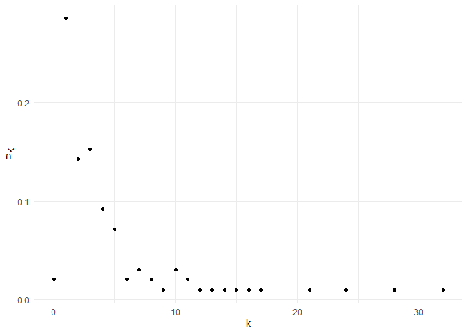

```r
ggplot(dist) +
  geom_point(aes(y=freq, x=grado)) +
  labs(x="k",y="Pk") +
  theme_minimal()
```

Ven ese pequeño punto en 0? Son las dos ocupaciones que tenían solo una conexión consigo mismas y que removimos esas aristas con **simplify**. Vamos a filtrarla

```r
grafo <- grafo %>% activate(nodes) %>% filter(!grado == 0)
```

Perfecto. Ahora prestemos atención a cuáles son las ocupaciones con mayor cantidad de aristas:

```r
grafo %>% activate(nodes) %>% arrange(desc(grado)) %>% as_tibble()
```

```
## # A tibble: 96 x 4
##    name    nodo  Desc                                                grado
##    <chr>   <chr> <chr>                                               <dbl>
##  1 11-9190 nodo  Miscellaneous Managers                                 32
##  2 37-2010 nodo  Building Cleaning Workers                              28
##  3 53-3030 nodo  Driver/Sales Workers and Truck Drivers                 24
##  4 51-9190 nodo  Miscellaneous Production Workers                       21
##  5 43-6010 nodo  Secretaries and Administrative Assistants              17
##  6 53-7060 nodo  Laborers and Material Movers, Hand                     16
##  7 41-2030 nodo  Retail Salespersons                                    15
##  8 35-1010 nodo  Supervisors of Food Preparation and Serving Workers    14
##  9 47-2060 nodo  Construction Laborers                                  13
## 10 41-2010 nodo  Cashiers                                               12
## # ... with 86 more rows
```

Estas son las ocupaciones que, según nuestra medida de similitud, más conexiones tienen hacia otras ocupaciones. Para empezar, es interesante ver que las que están clasificados como “otros” (Miscellaneous) se ubican en las primeras posiciones. Esto tiene sentido y es naturalmente un hecho de que allí se van clasificando “casos difíciles” que pueden clasificarse en algunos otros lugares dependiendo del encuestador/a. Recuerden que se trata de una encuesta, al final del día: las similitudes se toman en base a qué tan frecuente es moverse entre ocupaciones.

Ya vamos a volver a estas medidas de centralidad, pero ahora estudiemos el **diámetro** de nuestra red, es decir la distancia directa más larga entre cualquier par de nodos. Lo podemos lograr fácilmente con **diameter()**, en este caso del paquete igraph.

```r
igraph::diameter(grafo)
```

```
## [1] 6
```

Esto quiere decir que las dos ocupaciones más alejadas entre ellas tienen 6 aristas que las conecten. Conseguir los caminos es un poco más díficil de lo que debería, pero todo tiene solución. Por un lado, tenemos que usar la función **shortest_paths()**. Le pasamos un grafo, un nodo de salida y entrada y le decimos que queremos obtener tanto los nodos como las aristas que unen a esos dos puntos. Esto parece fácil, pero hay que hacer un par de pasos intermedios. Para empezar, nuestros nodos no tienen ID. la función **V()** de igraph nos permite agregar esta información

```r
grafo <- grafo %>%
         activate(nodes) %>%
         mutate(nodeID=V(.))
```

```r
salida <- grafo %>%
activate(nodes) %>%
  filter(name == "15-1120") %>%
  pull(nodeID)

llegada <- grafo %>%
  activate(nodes) %>%
  filter(name == "51-6050") %>%
  pull(nodeID)

path <- shortest_paths(
  graph = grafo,
  from = salida,
  to = llegada,
  output = 'both'
)
```

El problema es que nos devuelve una lista. La primera posición tiene a los vértices que conforman el camino, mientras que la segunda tiene a las aristas. Solo nos queda armarlo. Para esto, del grafo inicial le pedimos las arsitas que conforman al camino y lo convertimos a un objeto tiydgraph, de nuevo

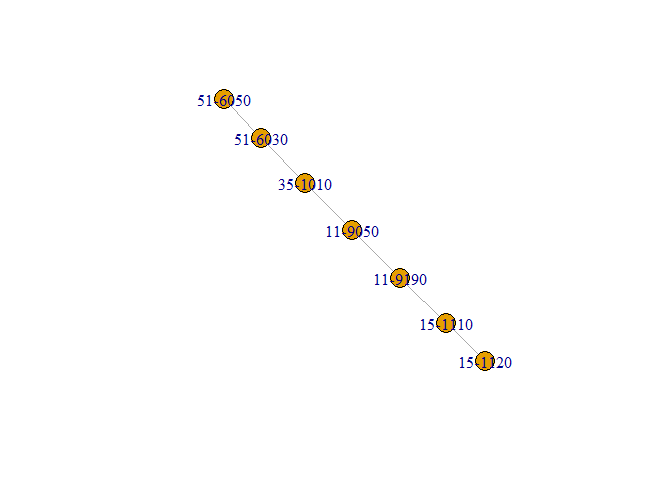

```r
camino <- grafo %>%
    subgraph.edges(eids = path$epath %>% unlist()) %>%
    as_tbl_graph()
plot(camino)
```

Esta es una de las máximas distancias en nuestra red. No se preocupen, ya vamos a ver como hacer mejores gráficos que este con ggraph. Por el momento les voy a contar cómo fue que sabía cual era la distanica más larga. La función **shortest.paths()** nos calcula para todos los nodos la distancia más corta contra el resto. Devuelve una matriz, y la diagonal principal es 0 ya que no hay distancia entre un nodo y si mismo.

```r
distancias <- shortest.paths(grafo)
```

Esta matriz podemos convertirla en algo que podemos trabajar con lo que ya sabemos de tidyverse (y alguna función nueva). Para empezar, **as_tibble()** ya la conocen: convierte a un objeto en un tibble, una versión mejorada de los data.frame. Dentro de esa función usamos rownames=NA, para que se quede con los nombres de las filas de la matriz, que tiene información sobre nuestros nodos. Después usamos **rownames_to_column()**, función que copia los nombres de las filas y las pega en una nueva columna que se llama *rownames*, que pone en la primera posición. Luego ya es terreno conocido: **pivot_longer()** para que pase a formato largo y **rename()** para emprolijar los nombres de las columnas. Además, ordenamos de mayor a menor según la distancia

```r
distancias %>%
  as_tibble(rownames = NA) %>%
  rownames_to_column() %>%
  pivot_longer(.,cols =2:ncol(.)) %>%
  rename(nodo1=rowname,
         nodo2=name,
         distancia=value) %>%
  arrange(desc(distancia))
```

```
## # A tibble: 9,216 x 3
##    nodo1   nodo2   distancia
##    <chr>   <chr>       <dbl>
##  1 11-9010 25-3000         6
##  2 11-9010 25-2050         6
##  3 15-1120 39-9020         6
##  4 15-1120 51-6050         6
##  5 15-1130 39-9020         6
##  6 15-1130 51-6050         6
##  7 25-2030 51-6050         6
##  8 25-3000 11-9010         6
##  9 25-3000 45-4020         6
## 10 25-3000 47-2070         6
## # ... with 9,206 more rows
```

```r
grafoParaGrafico <- grafo %>%
         activate(nodes) %>%
         mutate(betweness=centrality_betweenness(),
                clusteringLocal=local_transitivity()) %>%
         arrange(desc(betweness))
grafoParaGrafico
```

```
## # A tbl_graph: 96 nodes and 237 edges
## #
## # An undirected simple graph with 1 component
## #
## # Node Data: 96 x 7 (active)
##   name    nodo  Desc                    grado nodeID   betweness clusteringLocal
##   <chr>   <chr> <chr>                   <dbl> <igrph.>     <dbl>           <dbl>
## 1 11-9190 nodo  Miscellaneous Managers     32  7           1832.          0.0585
## 2 37-2010 nodo  Building Cleaning Work~    28 32           1064.          0.148
## 3 43-6010 nodo  Secretaries and Admini~    17 52            615.          0.221
## 4 53-3030 nodo  Driver/Sales Workers a~    24 78            615.          0.167
## 5 51-9190 nodo  Miscellaneous Producti~    21 76            439.          0.233
## 6 47-2060 nodo  Construction Laborers      13 61            317.          0.321
## # ... with 90 more rows
## #
## # Edge Data: 237 x 3
##    from    to arista
##   <int> <int> <chr>
## 1     1    46 aristas
## 2    46    63 aristas
## 3     7    46 aristas
## # ... with 234 more rows
```

Las medidas de centralidad dependen mucho de la pregunta que nos queremos hacer, y no siempre coinciden. La cantidad de grados nos da una idea de las conexiones directas, pero no dice nada sobre las indirectas. Betweness nos da una idea de si ese nodo debe ser usado para hacer caminos más cortos entre distintos nodos, mientras que clustering local nos dice que tan densa es la zona donde está ubicado el nodo. Todas estas medidas pueden ser relevantes para preguntas diferentes.

# Gráficando nuestras redes

Hace algunos años, graficar grafos en R implicaba aprender a fondo los parámetros dentro de **plot()**. Con **ggraph()** podemos aprovechar las economías de escala y hacer gráficos con nodos. Veamos algunos ejemplos

```
## Using `stress` as default layout
```

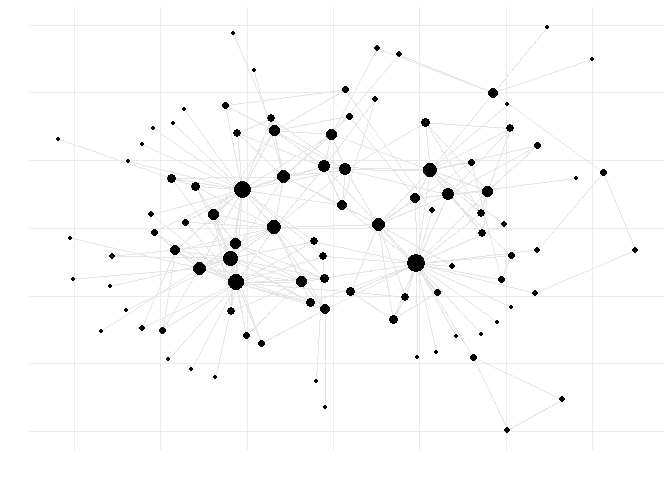

```r
ggraph(grafoParaGrafico) +
  geom_edge_link(color="grey90") +
  geom_node_point(aes(size=grado)) +
  theme_minimal() +
  guides(size=FALSE) +
  labs(x="",y="") +
  theme(axis.text = element_blank())
```

Este primer ejemplo deja muchas cosas en claro. Para empezar, nuestros gráficos deben comenzar con **ggraph()**, de esa manera se sabe que vamos a arrancar con un gráfico. Por otro lado, la idea de **geom_** de ggplot queda instacta. **geom_edge_link()** es para definir las aristas y sus propiedades. En este caso, queremos que aparezcan en gris con trasparencia al 90% (“grey90”), un valor apenas visible. Por su parte, **geom_node_point()** es usado para poder cambiar la apariencia de los nodos, en este caso queremos que el tamaño sea proporcional a la cantidad de de grados. Luego son todos comandos clásicos de ggplot: theme_minimal(), guides(), labs() y, finalmente, theme().

Uno de los puntos más importantes de los grafos es cómo los diponemos espacialmente. Por definición, la posición en donde pongamos los nodos es principalmente arbitraria. En general, al disposición óptima dependerá de cuál es el mensaje que queremos transmitir. igraph nos da un conjunto de **layouts**, que son algoritmos que fuerzan cierta disposición espacial de los nodos. Los pueden ver en **igraph::** y escribiendo layout. Por ejemplo, acá se muestra una disposición **star**

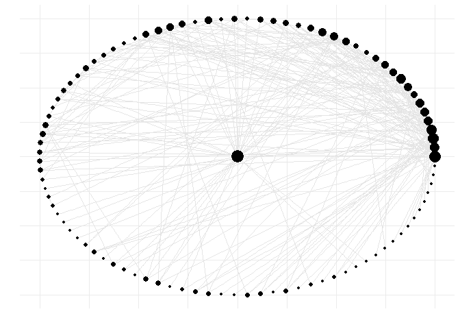

```r
ggraph(grafoParaGrafico,layout = 'igraph',algorithm="star") +
  geom_edge_link(color="grey90") +
  geom_node_point(aes(size=grado)) +
  theme_minimal() +
  guides(size=FALSE) +
  labs(x="",y="") +
  theme(axis.text = element_blank())
```

Por último, en los grafos muchas veces suele ser útil agregar etiquetas que nos identifiquen a los nodos gráficamente, particularmente cunado hay pocos nodos. Incluso podemos elegir algún tipo de crterio para mostrar solo algunos de los nodos para hacer que presten atención a ellos solos. Solo debemos agregar **geom_node_text()** para que incorpore el texto

```
## Using `stress` as default layout
```

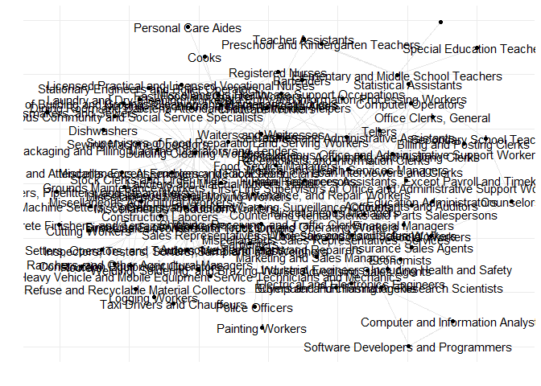

```r
ggraph(grafoParaGrafico) +
  geom_edge_link(color="grey90") +
  geom_node_point() +
  geom_node_text(aes(label=Desc)) +
  theme_minimal() +
  guides(size=FALSE) +
  labs(x="",y="") +
  theme(axis.text = element_blank())
```

No nos quedó muy bien… algo que podemos hacer, por ejemplo, es mostrar los primeros 10 nodos con mayor valor de centralidad de betwenness:

```
## Using `stress` as default layout
```

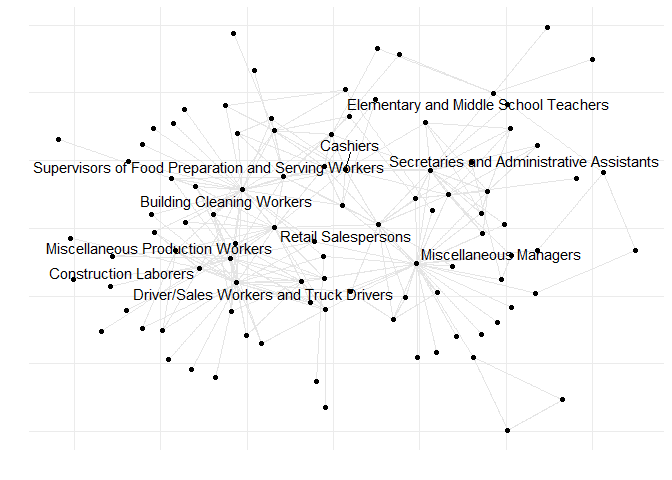

```r
grafoParaGrafico <- grafoParaGrafico %>%
      activate(nodes) %>%
      mutate(DescGrafico=ifelse(row_number() %in% 1:10, Desc,NA))

ggraph(grafoParaGrafico) +
  geom_edge_link(color="grey90") +
  geom_node_point() +
  geom_node_text(aes(label=DescGrafico),repel = TRUE) +
  theme_minimal() +
  guides(size=FALSE) +
  labs(x="",y="") +
  theme(axis.text = element_blank())
```

# Bibliografía y extensiones

Un gran libro para introducirse y profundizar conceptos de redes es [Network Science](http://networksciencebook.com/), de László Barabási. Pueden aprovechar que la versión online es gratuita. Por otro lado, el creador de tidygraph y otros paquetes tiene una [charla muy interesante sobre tidygraph](https://rstudio.com/resources/rstudioconf-2018/tidying-up-your-network-analysis-with-tidygraph-and-ggraph/), e incluso existe una introducción para analizar [grafos y datos espaciales](https://www.r-spatial.org/r/2019/09/26/spatial-networks.html)